# Friction Surface and Travel Time Tutorial

# Friction surface and travel time tutorial

## Data Preparation

First, we set up the working directory. This would be the current folder where this script is located.

Now we will download and extract the zip file containing all the datasets required for this exercise. The downloaded file should be around 67 Mb.

```r
# Download the zip file from GitHub
download.file(
  "https://github.com/enzocampomanesv/friction-travel-time-data/blob/main/dataset/friction-travel-time-dataset.zip?raw=TRUE",
  "friction-travel-time-dataset.zip",
  mode = "wb"
)
```

```r
# Extract the zip file
unzip("friction-travel-time-dataset.zip", exdir="Data")
```

We also prepare all the output folders ahead.

```r
dir.create("Data/Processed/")
subfolder_names <- c("rElevation","rFriction_100m","rLandcover","rLandcover_merge","rSlope",
                     "vRoads","vWater_lines","vWater_poly")
for (j in 1:length(subfolder_names)){
  dir.create(paste0("Data/Processed/",subfolder_names[j]))
}
```

Then we import the libraries needed and clear any existing variables in the R environment.

```r
library(dplyr)
library(terra)
library(sf)
library(doParallel)
library(foreach)
library(snow)
library(osmextract)
library(ggplot2)
library(raster)
library(tidyterra)
library(cowplot)
library(RColorBrewer)

rm(list=ls(all=TRUE))
```

Next, we load the datasets needed to create the friction surface.

### Admin boundary

First, we load the administrative boundary of the country we will be processing. In this case, Rwanda. The administrative boundary of Rwanda was downloaded from the GADM website. Also, we have a projections file which relates our country of interest to its EPSG code. It is also possible to have multiple country boundaries for multi-country analysis.

```r
admin <- st_read("Data/Admin/GADM/gadm41_RWA_0.shp")
```

```r
projections <- read.csv("Data/Admin/RWA_projections.csv")
```

We then get projection data (proj4 definitions) from EPSG and merge it with our projections data.

```r
# fetch projection data from EPSG
epsg <- read.csv("Data/Admin/epsg_codes.csv")
projections <- left_join(projections, epsg, by = c("epsg_code"  ="code"))
```

Finally, we join those projections to our administrative boundary. We also save the country code (GID_0) to be used for file saving later on.

```r
# create landcover for each country in ssa
admin <- left_join(admin, projections, by = c("GID_0" = "country_code")) # merge the projections to the spatial data
countries <- admin$GID_0
file_name <- admin$COUNTRY
```

We will be using this boundary in the subsequent parts of the data preparation.

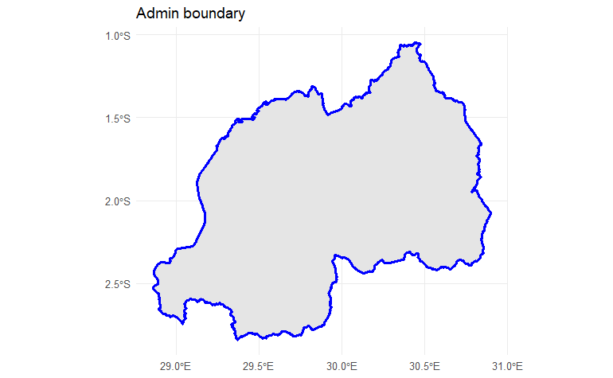

```r
#Visualize the data
ggplot()+
  geom_sf(data = admin,
          aes(geometry=geometry),
          color = "blue",
          size = 1)+
  ggtitle("Admin boundary") +
  theme_minimal()
```

### Land cover, elevation, slope

Next, we load the land cover dataset from Buchorn et al (2020) DOI: 10.5281/zenodo.3939050. To save on memory, we have already clipped the land cover and elevation datasets to Rwanda. However, these datasets are globally available so this exercise can be replicated for any country/area. You would just need to replace the datasets we have provided with the global ones.

```r
landcover <- rast("Data/LandCover/RWA_PROBAV_LC100_global_v3.0.1_2019.tif")
elevation <- rast("Data/Elevation/COPDEM90m_RWA.tif")
```

Assuming you have the global datasets, in this next block of code, we take the land cover and elevation data and clip only within our country/countries of interest. And we export that clip to a TIF file. Nevertheless, still run this chunk of code to avoid any confusion with the file names.

```r
system.time(for(i in 1:nrow(admin)) {
  l = landcover
  e = elevation
  a = admin %>%
    filter(GID_0 == countries[i])
  a = vect(a)

  # clip land cover
  r_l = terra::crop(l, a)
  m_l = terra::mask(r_l, a)
  p_l = terra::project(m_l, admin$prj4[i], method = "near")
  values(p_l)[values(p_l) == 0] <- NA
  writeRaster(p_l, paste0("Data/Processed/rLandcover/landcover_", countries[i], ".tif"), overwrite=T)

  # clip elevation
  r_e = terra::crop(e, a)
  m_e = terra::mask(r_e, a)
  p_e = terra::project(m_e, admin$prj4[i], method = "near")
  writeRaster(p_e, paste0("Data/Processed/rElevation/elevation_", countries[i], ".tif"), overwrite=T)

})
```

We can check the written rasters in the “Processed” folder and visualize the land cover and elevation in your preferred GIS software. After clipping the elevation, we calculate the slope.

```r
for(i in 1:nrow(admin)){
  # load in elevation
  elevation <- rast(paste0("Data/Processed/rElevation/elevation_", countries[i], ".tif"))
  slope <- terrain(elevation, v="slope")

  writeRaster(slope, paste0("Data/Processed/rSlope/slope_", countries[1], "_terra.tif"), overwrite=T)
}
```

Here, we then visualize the clipped elevation, land cover, and slope.

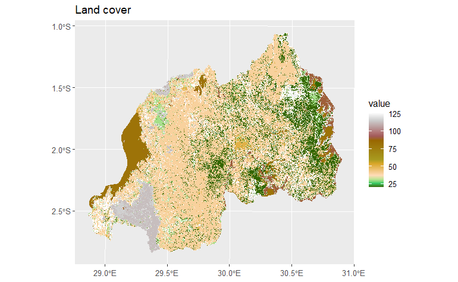

```r
#Visualize the data
ggplot()+
  geom_spatraster(data=p_l, aes(fill=!!!names(p_l)))+
  scale_fill_hypso_c()+
  ggtitle("Land cover")
```

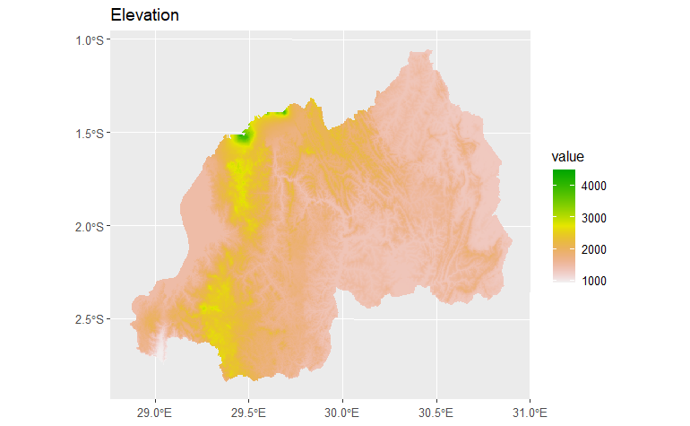

```r
ggplot()+
  geom_spatraster(data=p_e, aes(fill=!!!names(p_e)))+
  scale_fill_terrain_c()+
  ggtitle("Elevation")
```

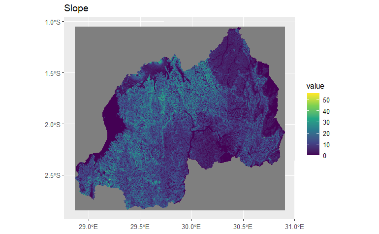

```r
ggplot()+
  geom_spatraster(data=slope, aes(fill=!!!names(slope)))+
  scale_fill_viridis_c()+
  ggtitle("Slope")
```

### OpenStreetMap data

Since we will be getting our data for roads, waterways, and waterbodies from OpenStreetMap, we will first prepare our queries for each of these datasets.

#### Queries

```r
road_query = "SELECT * FROM 'lines' WHERE highway IS NOT NULL"
waterway_query = "SELECT * FROM 'lines' WHERE waterway IS NOT NULL AND waterway == 'river'" # here, we only take the main river line and exclude streams and other small waterways
waterbody_query = "SELECT * FROM 'multipolygons' WHERE water IS NOT NULL"
```

#### Extracting data

For more efficient processing, we want to do parallel processing and use multiple (but not all!) of our computer’s resources.

```r
# assign cores for parallel processing
cores <- 3 # not to overload your computer
cl <- makeCluster(cores)
registerDoParallel(cl)
```

Then, using the query we built for each dataset, we take the roads, waterways, and water bodies only within the country/countries of interest. We do this by looping through all the countries but in this case, we only have one country: Rwanda.

```r
# system.time(foreach(i = 1:length(admin), .packages= c("sf", "osmextract")) %dopar% {
  # Get the data using the query
for(i in seq(1:nrow(admin))){
  roads = oe_get(
    paste(file_name[i]),
    quiet = FALSE,
    query = road_query)

  waterway = oe_get(
    paste(file_name[i]),
    quiet = FALSE,
    query = waterway_query)

  waterbody = oe_get(
    paste(file_name[i]),
    extra_tags = c("water"),
    quiet = FALSE,
    query = waterbody_query)

  st_crs(roads) = st_crs(admin)
  st_crs(waterway) = st_crs(admin)
  st_crs(waterbody) = st_crs(admin)

  roads = st_transform(roads, crs=admin$prj4[i])
  waterway = st_transform(waterway, crs=admin$prj4[i])
  waterbody = st_transform(waterbody, crs=admin$prj4[i])

  st_write(roads, paste0("Data/Processed/vRoads/Roads_", countries[i], ".shp"),delete_dsn=T)
  st_write(waterway, paste0("Data/Processed/vWater_lines/Water_lines_", countries[i], ".shp"), append = F, delete_dsn=T)
  st_write(waterbody, paste0("Data/Processed/vWater_poly/Water_poly_", countries[i], ".shp"), append = F, delete_dsn=T)
}
```

We can now inspect the vector outputs from OSM.

```r
ggplot()+
  geom_sf(data = roads, aes(geometry = geometry), color = "gray", size=0.15)+
  geom_sf(data = waterbody, aes(geometry = geometry), fill = "lightblue", color=NA, size=0.5)+
  geom_sf(data = waterway, aes(geometry = geometry), color = "blue", size=0.25)+
  geom_sf(data = admin, aes(geometry = geometry), color = "black", fill=NA, size=1)+
  ggtitle("OpenStreetMap layers")
```

[output not shown]

This is the end of the individual dataset preparation.

## Merging datasets

In this phase, we merge the landcover, roads, waterways, and waterbodies.

```r
# load in data layers
# the administrative boundaries can be adapted to personal requirements. Here we used the GADM boundaries:
# available from: https://gadm.org/data.html
landcover <- c(list.files("Data/Processed/rLandcover", recursive = T, full.names = T, pattern = "*.tif$"))
roads <- c(list.files("Data/Processed/vRoads", recursive = T, full.names = T, pattern = "*.shp$"))
water_lines <- c(list.files("Data/Processed/vWater_lines", recursive = T, full.names = T, pattern = "*.shp$"))
water_poly <- c(list.files("Data/Processed/vWater_poly", recursive = T, full.names = T, pattern = "*.shp$"))
```

We first list all the road classes that are found in the OSM road data and reclassify each class to an integer value.

```r
road_classes <- c("motorway", "trunk", "primary", "secondary", "tertiary",
                  "unclassified", "residential", "motorway_link", "trunk_link",
                  "primary_link", "secondary_link", "tertiary_link", "living_street",
                  "service", "pedestrian", "track", "road", "footway", "bridleway",
                  "steps", "path", "cycleway", "raceway", "unclassified", "bridge")

reclass_roads <- list(
  "trunk" = 1001,
  "trunk_link" = 1002,
  "primary" = 1003,
  "primary_link"= 1004,
  "motorway" = 1005,
  "motorway_link" = 1006,
  "secondary" = 1007,
  "secondary_link" = 1008,
  "tertiary" = 1009,
  "tertiary_link" = 1010,
  "road" = 1011,
  "raceway" = 1012,
  "residential" = 1013,
  "living_street" = 1014,
  "service" = 1015,
  "track" = 1016,
  "pedestrian" = 1017,
  "path" = 1018,
  "footway" = 1019,
  "piste" = 1020,
  "bridleway" = 1021,
  "cycleway" = 1022,
  "steps" = 1023,
  "unclassified" = 1024,
  "bridge" = 1025)
```

```r
landcover_merge_function <- function(i) {
  landcov <- rast(landcover[i]) # load landcover raster
  grid_landcov <- rast(ext(landcov))
  res(grid_landcov) <- 100
  crs(grid_landcov) <- crs(landcov)
  landcover_resamp  <- resample(landcov, grid_landcov, "near") # resample landcover to 100m

  roads_new <- st_read(roads[i]) %>%
    group_by(highway) %>%
    summarize() %>%
    filter(highway %in% as.factor(road_classes)) %>%
    mutate(class = recode(highway, !!!reclass_roads),
           class = as.integer(class)) %>% # give all road classes an integer value, so they can be represented in the raster
    st_transform(st_crs(landcov)) %>%
    vect()
  roads_rast <- terra::rasterize(roads_new, grid_landcov, "class", touches = TRUE) # rasterize roads to 100 meters

  water_lines_new <- st_read(water_lines[i]) %>% # load water lines
    group_by(waterway) %>%
    summarize() %>%
    filter(waterway == "river") %>% # filter only hydrography lines classified as river
    mutate(class = 80) %>% # give all rivers and integer class 1 so that later they can be classified as barriers
    st_transform(st_crs(landcov)) %>%
    vect()
  water_lines_rast <- terra::rasterize(water_lines_new, grid_landcov, field = "class", touches = TRUE) # rasterize water lines
  values(water_lines_rast)[values(water_lines_rast) == 0] <- NA # make background value NA

  water_poly_new <- st_read(water_poly[i]) %>% # load water polygons
    mutate(class = 80) %>% # give all rivers and lakes integer class 1 so that later they can be classified as barriers
    st_transform(st_crs(landcov)) %>%
    vect()
  water_poly_rast <- terra::rasterize(water_poly_new, grid_landcov, "class", touches = TRUE) # rasterize water polygons
  values(water_poly_rast)[values(water_poly_rast) == 0] <- NA # make background value NA

  # add in the following sequence from bottom to top all the raster layers (landcover, water lines, water polygons, roads)
  landcover_merge <- terra::merge(water_lines_rast, landcover_resamp)
  landcover_merge <- terra::merge(water_poly_rast, landcover_merge)
  landcover_merge <- terra::merge(roads_rast, landcover_merge)
  # all values that are 1 represent waterbodies, set to 80 or the class of permanent waterbodies
  #values(landcover_merge)[values(landcover_merge) == 1] <- 80

  # export the merged layer to a TIF
  writeRaster(landcover_merge, paste0("Data/Processed/rLandcover_merge/landcover_merge_", file_name[i], ".tif"), overwrite=T)
}
```

Before we run the function, we prepare our computer by assigning resources and also providing a temporary folder to keep intermediate outputs to prevent using too much memory in the R environment.

```r
# parallel processing of landcover merge
cores <- 3 # not to overload your computer
cl <- makeCluster(cores)
registerDoParallel(cl)
terraOptions(tempdir="/temp/") # set temporary folder for data processing, so R environment does not have memory issues
```

Here, we run the function we just defined above.

```r
system.time(foreach(i = 1:length(landcover),
                    .packages= c("sf", "dplyr", "terra"))
                    %dopar% {landcover_merge_function(i)})
```

Finally, we can visualize the merged land cover raster. You can also visualize this in your preferred GIS software.

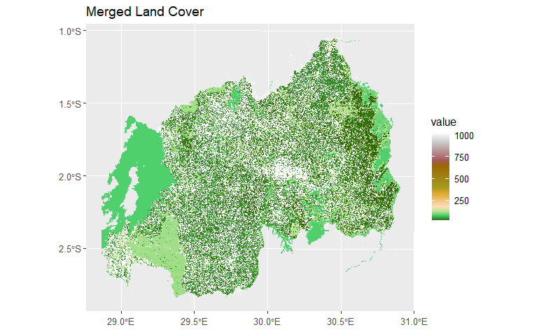

```r
lc_merge <- rast(paste0("Data/Processed/rLandcover_merge/landcover_merge_", file_name[i], ".tif"))

ggplot()+
  geom_spatraster(data=lc_merge, aes(fill=!!!names(lc_merge)))+
  scale_fill_hypso_c()+
  ggtitle("Merged Land Cover")
```

This is the end of the data preparation segment.

## Creating the friction surface

Next, we will use this dataset to create the friction surface. We will also need additional libraries for the next steps. Here, we load them.

```r
library(readxl)
library(plyr)
library(terra)
```

We also reset and remove existing variables again to avoid any confusion.

```r
rm(list=ls(all=TRUE))
```

In this process, first we load the admin boundaries of our country of interest and the merged land cover file we created in the previous step.

```r
admin <- st_read("Data/Admin/GADM/gadm41_RWA_0.shp")
```

```r
projections <- read.csv("Data/Admin/RWA_projections.csv")
# fetch projection data from EPSG
epsg <- read.csv("Data/Admin/epsg_codes.csv")
projections <- left_join(projections, epsg, by = c("epsg_code"  ="code"))
admin <- left_join(admin, projections, by = c("GID_0" = "country_code")) # merge the projections to the spatial data

landcover <- c(list.files("Data/Processed/rLandcover_merge", recursive = T, full.names = T, pattern = "*.tif$")) # land cover merge for each country
elev <- c(list.files("Data/Processed/rElevation", recursive = T, full.names = T, pattern = "*.tif$"))
slop <- c(list.files("Data/Processed/rSlope", recursive = T, full.names = T, pattern = "*.tif$"))
```

## Speed data

Then we load two spreadsheets. The first defines the speeds per road class and second defines the speeds per land cover class.

The speeds per road class were taken from Weiss et al. (2020) and are specific to each country but also provide a global default. Below are the speeds for Rwanda.

| Road Class | Speed (km/h) |
| --- | --- |
| trunk | 40 |
| primary | 40 |
| secondary | 40 |
| tertiary | 40 |
| unclassified | 40 |
| residential | 40 |
| service | 35 |
| track | 40 |
| other | 40 |

The speeds per land cover class were taken from Weiss et al. (2018) and are general, which means they don’t vary from country to country. Below are the speeds per land cover class.

| Land Cover Class | Speed (km/h) |
| --- | --- |
| unknown | 3 |
| shrubs | 3.6 |
| herbaceous vegetation | 3.24 |
| cultivated/agriculture | 2.5 |
| urban/built up | 5 |
| bare/sparse vegetation | 3 |
| snow and ice | 1.62 |
| permanent waterbodies | 2 |
| unclassified | 3 |
| herbaceous wetland | 2 |
| moss and lichen | 3.24 |
| closed forest, evergreen needle leaf | 3.24 |
| closed forest, evergreen broad leaf | 1.62 |
| closed forest, deciduous needle leaf | 3.24 |
| closed forest, deciduous broad leaf | 4 |
| closed forest, mixed | 3.24 |
| closed forest, not matching other definitions | 3.07 |
| open forest, evergreen needle leaf | 3.24 |
| open forest, evergreen broad leaf | 1.62 |
| open forest, deciduous needle leaf | 3.24 |
| open forest, deciduous broad leaf | 4 |
| open forest, mixed | 3.24 |
| open forest, not matching other definitions | 3.07 |
| oceans, seas | 1 |

Load the spreadsheets containing the different speeds.

```r
travelspeeds <- read_xlsx("Data/Weiss2020_OSM_speedsFriction.xlsx",
                          sheet = "Sheet1") # speeds coming from Weiss et al (2020)
landcoverspeeds <- read_xlsx("Data/Weiss2018_LC_speedsFriction.xlsx") # table containing the speeds for the different land cover classes
```

Subset the country names, road classes, and land cover classes

```r
countries <- admin$GID_0
road_classes <- c(1001:1025)
landcover_classes <- landcoverspeeds$Class
```

## Joining roads and land cover with speed data

Create a data frame with countries and road classes so a travel scenario can be extracted for each country using the road speeds from Weiss et al. (2020). If the class does not have a match in the Weiss et al. (2020) sheet, we use the speed defined in the “other” class. Lastly, we do a conversion of the speed from km/h to min/m.

```r
countries <- rep(countries, each = length(road_classes))
road_classes <- rep(road_classes, length(unique(countries)))
data_roads <- data.frame(country = countries, road_class = road_classes) %>%
  mutate(osm_class = recode(road_class,
                        '1001' = "trunk",
                        '1002' = "trunk_link",
                        '1003' = "primary",
                        '1004' = "primary_link",
                        '1005' = "motorway",
                        '1006' = "motorway_link",
                        '1007' = "secondary",
                        '1008' = "secondary_link",
                        '1009' = "tertiary",
                        '1010' = "tertiary_link",
                        '1011' = "road",
                        '1012' = "raceway",
                        '1013' = "residential",
                        '1014' = "living_street",
                        '1015' = "service",
                        '1016' = "track",
                        '1017' = "pedestrian",
                        '1018' = "path",
                        '1019' = "footway",
                        '1020' = "piste",
                        '1021' = "bridleway",
                        '1022' = "cycleway",
                        '1023' = "steps",
                        '1024' = "unclassified",
                        '1025' = "bridge")) %>% # reclassify the different road classes
  left_join(., travelspeeds, by = c("country" = "ISO3", "osm_class" = "osm_class")) %>% # merge the empty table with the Weiss et al table
  mutate(weiss_class = ifelse(is.na(speed) == TRUE, "other", osm_class))  %>% # if Weiss table does not have a speed for a certain category, assign the class "other" to a new column
  dplyr::select(-c(GAUL, country_name, osm_tag_name, speed)) %>% # only keep important columns
  left_join(., travelspeeds, by = c("country" = "ISO3", "weiss_class" = "osm_class")) %>% # join travel speeds of weiss again, including the "other" category
  mutate(conversion = ((60*1)/(speed*1000))) %>%  # the input of the accessibility analysis, requires a time cost of traversing one cell per meter. For 100m we change the first 1 to 100 for conversion.
  dplyr::select(c(country, country_name, osm_class, weiss_class, road_class, speed, conversion))
```

Now we do the same thing for the land cover classes and speeds.

```r
# create data frame for land cover classes
countries <- admin$GID_0
countries <- rep(countries, each = length(landcover_classes))
landcover_classes <- rep(landcover_classes, length(unique(countries)))

data_landcover <- data.frame(country = countries, landcover_class = landcover_classes) %>%
  mutate(landcover_label = recode(landcover_class,
                            '0'   = "unknown",
                            '20'  = "shrubs",
                            '30'  = "herbaceous vegetation",
                            '40'  = "cultivated/agriculture",
                            '50'  = "urban/built up",
                            '60'  = "bare/sparse vegetation",
                            '70'  = "snow and ice",
                            '80'  = "permanent waterbodies",
                            '81'  = "unclassified",
                            '90'  = "herbaceous wetland",
                            '100' = "moss and lichen",
                            '111' = "closed forest, evergreen needle leaf",
                            '112' = "closed forest, evergreen broad leaf",
                            '113' = "closed forest, deciduous needle leaf",
                            '114' = "closed forest, deciduous broad leaf",
                            '115' = "closed forest, mixed",
                            '116' = "closed forest, not matching other definitions",
                            '121' = "open forest, evergreen needle leaf",
                            '122' = "open forest, evergreen broad leaf",
                            '123' = "open forest, deciduous needle leaf",
                            '124' = "open forest, deciduous needle leaf",
                            '125' = "open forest, mixed",
                            '126' = "open forest, not matching other definitions",
                            '200' = "oceans, seas")) %>%
  left_join(., landcoverspeeds, by = c("landcover_class" = "Class")) %>%
  dplyr::select(-c(Label)) %>%
  mutate(conversion = ((60*1)/(speed*1000)))
```

Here, we merge both road and land cover speeds into one list.

```r
# split the full travel speed dataframe into separate list items
speeds_roads <- data_roads %>%
  dplyr::select(c(country, road_class, speed)) %>%
  dplyr::rename(class = "road_class")
speeds_landcover <- data_landcover %>%
  dplyr::select(c(country, landcover_class, speed)) %>%
  dplyr::rename(class = "landcover_class")
speeds <- rbind(speeds_roads, speeds_landcover) # merge both datasets
speeds_list <- list()
speeds_list <- split(speeds , f = speeds$country)
speeds_list <- lapply(speeds_list, function(x) { x["country"] <- NULL; x})
```

Then we resample the elevation and slope rasters to match the newly created merged land cover dataset. These two rasters will be used in the calculation of the friction surface as adjustment factors.

```r
# process elevation and slope
for(i in seq(1:nrow(admin))){
  landcover_merge <- rast(landcover[i]) # reference image

  elev_in <- rast(elev[i])
  grid_elev <- rast(ext(landcover_merge))
  res(grid_elev) <- 100
  crs(grid_elev) <- crs(landcover_merge)
  elevation  <- resample(elev_in, grid_elev) # resample elev to 100m

  slo_in <- rast(slop[i])
  grid_slo <- rast(ext(landcover_merge))
  res(grid_slo) <- 100
  crs(grid_slo) <- crs(landcover_merge)
  slope  <- resample(slo_in, grid_slo) # resample slope to 100m
}
```

Similar to previous runs, we allocate computing resources before running.

```r
cores <- 2 # not to overload your computer
cl <- makeCluster(cores)
registerDoParallel(cl)
```

## Calculating the friction surface

And finally, we calculate the friction surface. For land cover classes that are not roads, we multiply the speed with an elevation adjustment factor and slope adjustment factor, as explained in Weiss et al (2018).

```r
landcover_merge <- rast(landcover[1])
landcover_speed_orig <- classify(landcover_merge, speeds_list[[1]])

landcover_friction_orig <- 60/(landcover_speed_orig*1000)

admin_p <- st_transform(admin, admin$prj4[1])
admin_p = vect(admin_p)

landcover_friction_orig_c <- terra::crop(landcover_friction_orig, admin_p)
landcover_friction_orig_m <- terra::mask(landcover_friction_orig_c, admin_p)

# Only apply elevation adjustment factor to land cover classes that are not roads (class id < 1000)

# elevation adjustment factor
elev_adj <- 1.016*exp(-0.0001072*elevation[landcover_merge < 1000])

# slope adjustment factor
#   convert slope from degrees to radians (*0.01745) and applying tan() function
#   calculate Tobler's walking speed (6e(-3.5*|tan(theta|))
#   percentage of max walking speed = 5 km/h
slope_adj <- (6*exp(-3.5*abs(tan(0.01745*slope[landcover_merge < 1000])+0.05)))/5

# adjust land cover dependent speeds by elevation and slope adjustment factors
landcover_speed_adj <- landcover_speed_orig
landcover_speed_adj[landcover_merge < 1000] <-
  landcover_speed_adj[landcover_merge < 1000]*elev_adj*slope_adj
landcover_friction_adj <- 60/(landcover_speed_adj*1000)

landcover_friction_adj_c <- terra::crop(landcover_friction_adj, admin_p)
landcover_friction_adj_m <- terra::mask(landcover_friction_adj_c, admin_p)
friction_fname <- paste0("Data/Processed/rFriction_100m/friction_", countries[1], ".tif")
writeRaster(landcover_friction_adj_m, friction_fname,overwrite = T)
```

We now have a 100m resolution friction surface representing how many minutes it takes to travel one meter in that cell.

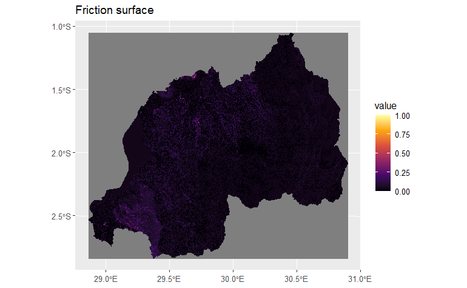

```r
ggplot()+
  geom_spatraster(data=landcover_friction_adj_m, aes(fill=!!!names(landcover_friction_adj_m)))+
  scale_fill_viridis_c(option="B", limits=c(0,1))+
  ggtitle("Friction surface")
```

## Calculating travel time to markets

Now that we have the friction surface, we can then calculate travel time to certain points of interest.

```r
install(pkg_path)
```

```r
2
```

[output not shown]

After installing the custom R library called rtravelcost, we will now load it.

```r
library(rtravelcost)
library(raster)
```

```r
memory.limit(999999999999)
```

```r
memory.size(999999999999)
```

```r
markets <- "Data/GHSL/GHS_SMOD_2020_RWA_U_IITAWFP_point.shp"
dir.create("Outputs/")
travel_time <- accumcosts(x = friction_fname,
                          y = markets,
                          # Travel time raster output
                          outputpath1="Outputs/travelTime_mins.tif",
                          # Travel time sheds output
                          outputpath2="Outputs/travelTime_shed.tif",
                          directions = 8,
                          nblocks = 1,
                          format="GTiff",
                          field="Id",
                          rollX=FALSE,
                          rollY=FALSE
                          )
```

We were able to use our 100m resolution friction surface to create (1) a travel time to markets surface at the same resolution and (2) a travel time shed raster.

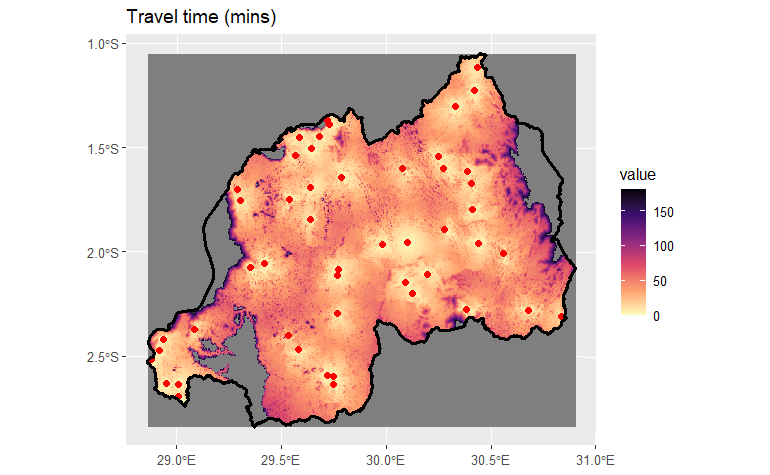

```r
travel_time <- rast("Outputs/travelTime_mins.tif")
travel_time_m <- terra::mask(travel_time, admin_p)
ggplot()+
  geom_spatraster(data=travel_time_m,
                  aes(fill=!!!names(travel_time_m)))+
  geom_sf(data= st_read(markets, quiet=TRUE),
          aes(geometry=geometry),
          color="red",
          fill="red",
          size=2)+
  geom_sf(data = admin_p,
          aes(geometry=geometry),
          color = "black",
          fill = NA,
          size = 1)+
  scale_fill_viridis_c(option="A", direction = -1, limits=c(0, 180))+
  ggtitle("Travel time (mins)")
```

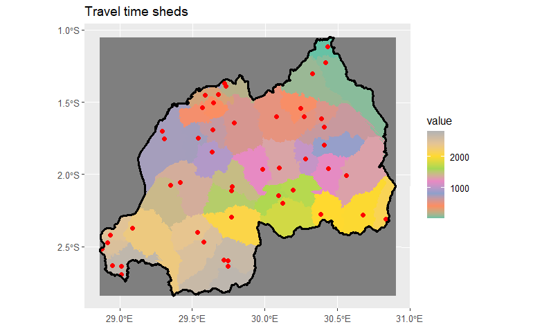

```r
travel_time_sheds <- rast("Outputs/travelTime_shed.tif")
travel_time_sheds_m <- terra::mask(travel_time_sheds, admin_p)
ggplot()+
  geom_spatraster(data=travel_time_sheds_m,
                  aes(fill=!!!names(travel_time_sheds_m)))+
  geom_sf(data= st_read(markets, quiet=TRUE),
          aes(geometry=geometry),
          color="red",
          fill="red",
          size=2)+
  geom_sf(data = admin_p,
          aes(geometry=geometry),
          color = "black",
          fill = NA,
          size = 1)+
  scale_fill_gradientn(colors= brewer.pal(8, "Set2"))+
  ggtitle("Travel time sheds")
```